# FIA - NLS Models: Biomass vs. Stand Age, G-Reconciled, Temporally-balanced – Log-Normal

## plot residuals

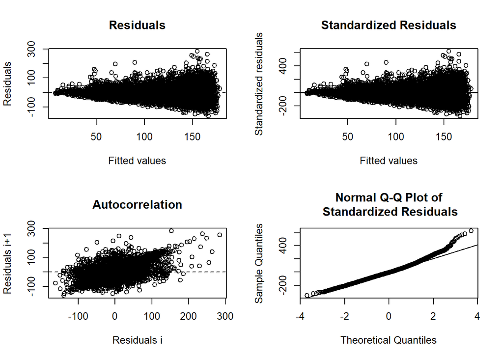

```
##
## ------
##  Shapiro-Wilk normality test
##
## data:  stdres
## W = 0.98535, p-value < 2.2e-16
##
##
## ------
```

```
##
##  Runs Test
##
## data:  as.factor(run)
## Standard Normal = -29.451, p-value < 2.2e-16
## alternative hypothesis: two.sided
```

## predict and plot

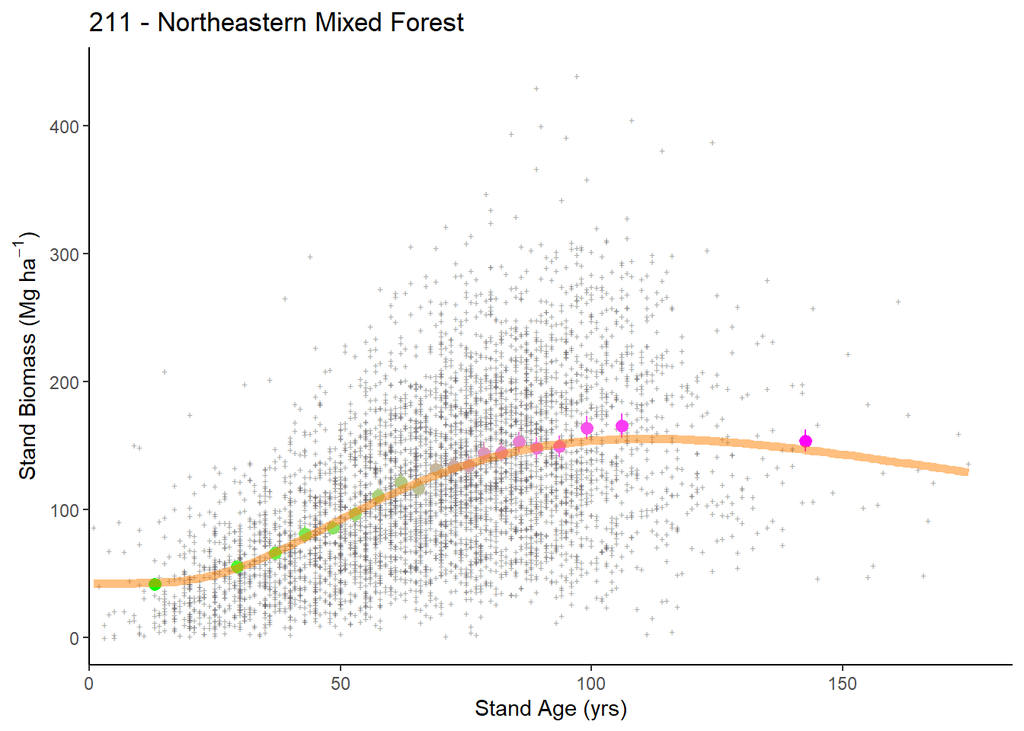

## plotting 2

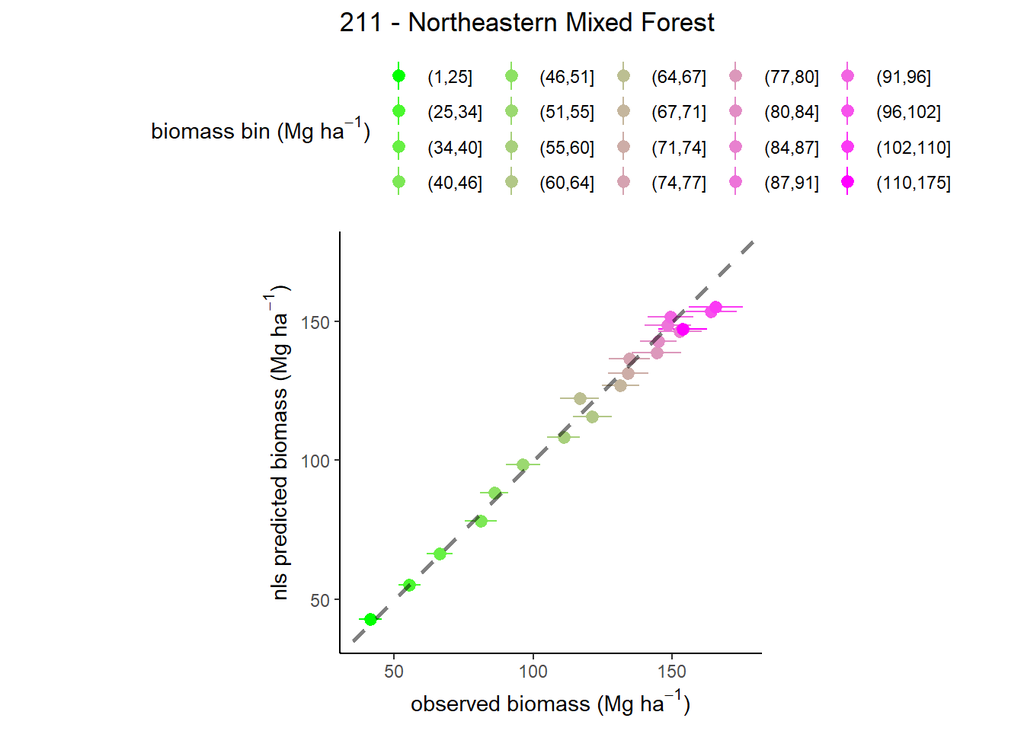

# 212 - Laurentian Mixed Forest

## model selection 1

```
## Analysis of Variance Table
##
## Model 1: B_plt_t2_MgHa ~ (1 + (MEASTIME_t2 - 1990) * ge/100) * (a + b * exp(-((log(STDAGE_t2/c))/d)^2))
## Model 2: B_plt_t2_MgHa ~ (1 + (MEASTIME_t2 - 1990) * ge/100) * (1 + phi * DeltaPDSI) * (a + b * exp(-((log(STDAGE_t2/c))/d)^2))
## Model 3: B_plt_t2_MgHa ~ (1 + (MEASTIME_t2 - 1990) * ge/100) * (1 + phi * DeltaPDSI) * (1 - alpha * B_L_prop) * (a + b * exp(-((log(STDAGE_t2/c))/d)^2))
##   Res.Df Res.Sum Sq Df  Sum Sq  F value Pr(>F)
## 1  11673     3884.8
## 2  11670     3884.8  3   0.009   0.0092 0.9988
## 3  11669     3655.0  1 229.868 733.8841 <2e-16 ***
## ---
## Signif. codes:  0 '***' 0.001 '**' 0.01 '*' 0.05 '.' 0.1 ' ' 1
##   model      AIC
## 1     1 121859.0
## 2     2 121840.8
## 3     3 121130.7
```

```
##
## Formula: B_plt_t2_MgHa ~ (1 + (MEASTIME_t2 - 1990) * ge/100) * (1 + phi *
##     DeltaPDSI) * (1 - alpha * B_L_prop) * (a + b * exp(-((log(STDAGE_t2/c))/d)^2))
##
## Parameters:
##        Estimate Std. Error t value Pr(>|t|)
## ge    7.063e-01  1.411e-01   5.007 5.61e-07 ***
## phi   1.029e-03  4.447e-03   0.231    0.817
## alpha 7.602e-01  2.335e-02  32.557  < 2e-16 ***
## a     2.318e+01  8.701e-01  26.638  < 2e-16 ***
## b     7.597e+01  2.501e+00  30.373  < 2e-16 ***
## c     1.105e+02  3.802e+00  29.059  < 2e-16 ***
## d     1.198e+00  3.831e-02  31.262  < 2e-16 ***
## ---
## Signif. codes:  0 '***' 0.001 '**' 0.01 '*' 0.05 '.' 0.1 ' ' 1
##
## Residual standard error: 0.5597 on 11669 degrees of freedom
##
## Algorithm "port", convergence message: relative convergence (4)
##   (12 observations deleted due to missingness)
```

### summary

- simple model: fits
- phi model: fits
- phi-alpha model: fits

## plot residuals

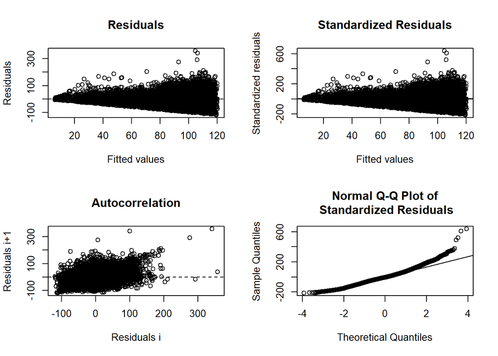

## predict and plot

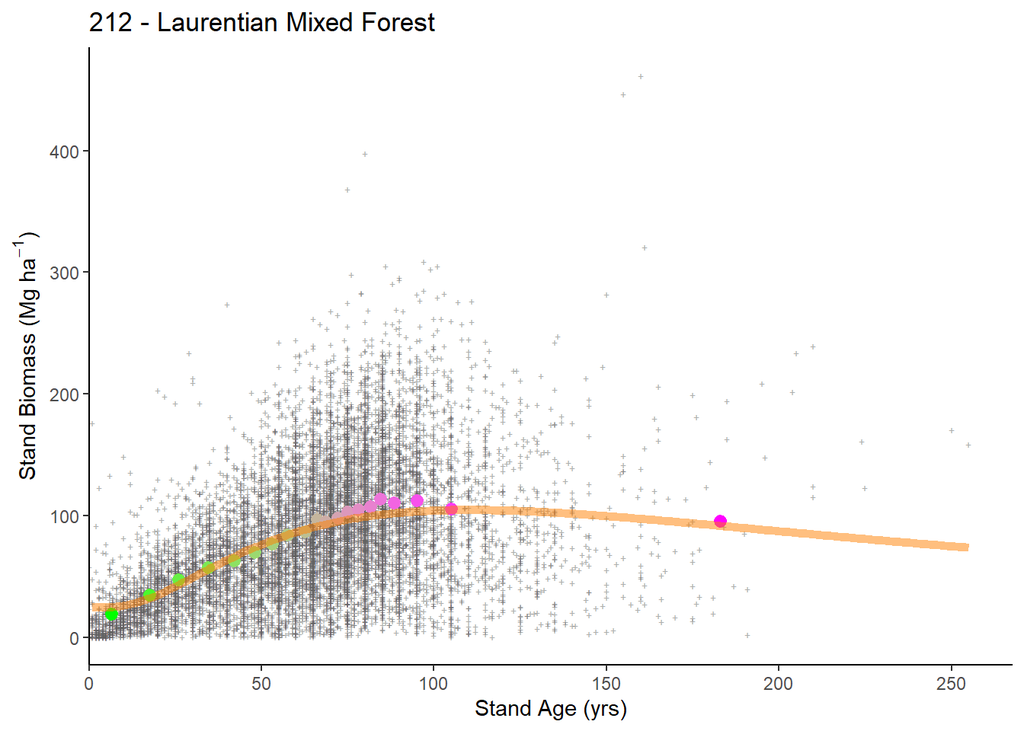

## plotting 2

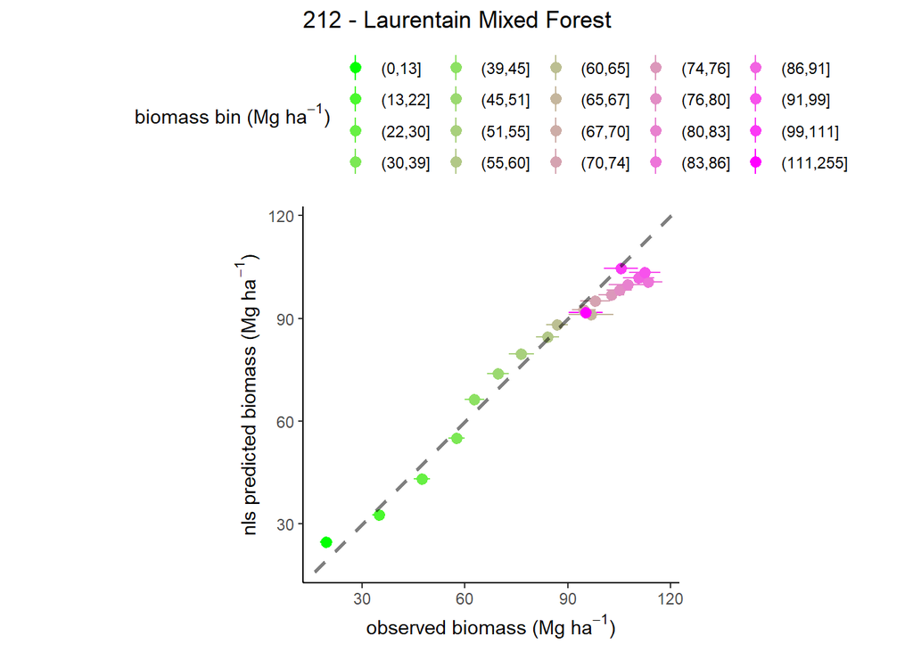

# 221 - Eastern Broadleaf Forest

## model selection 1

```
## Analysis of Variance Table
##
## Model 1: B_plt_t2_MgHa ~ (1 + (MEASTIME_t2 - 1990) * ge/100) * (a + b * exp(-((log(STDAGE_t2/c))/d)^2))
## Model 2: B_plt_t2_MgHa ~ (1 + (MEASTIME_t2 - 1990) * ge/100) * (1 + phi * DeltaPDSI) * (a + b * exp(-((log(STDAGE_t2/c))/d)^2))
## Model 3: B_plt_t2_MgHa ~ (1 + (MEASTIME_t2 - 1990) * ge/100) * (1 + phi * DeltaPDSI) * (1 - alpha * B_L_prop) * (a + b * exp(-((log(STDAGE_t2/c))/d)^2))
##   Res.Df Res.Sum Sq Df Sum Sq F value Pr(>F)
## 1   5344     890.76
## 2   5343     890.76  1  0.000   0.000      1
## 3   5336     795.58  7 95.181  91.198 <2e-16 ***
## ---
## Signif. codes:  0 '***' 0.001 '**' 0.01 '*' 0.05 '.' 0.1 ' ' 1
##   model      AIC
## 1     1 58367.50
## 2     2 58369.50
## 3     3 57719.02
```

```
##
## Formula: B_plt_t2_MgHa ~ (1 + (MEASTIME_t2 - 1990) * ge/100) * (1 + phi *
##     DeltaPDSI) * (1 - alpha * B_L_prop) * (a + b * exp(-((log(STDAGE_t2/c))/d)^2))
##
## Parameters:
##        Estimate Std. Error t value Pr(>|t|)
## ge    2.772e-01  1.408e-01   1.968   0.0491 *
## phi   0.000e+00  5.432e-03   0.000   1.0000
## alpha 8.254e-01  3.049e-02  27.073   <2e-16 ***
## a     3.112e+01  2.994e+00  10.396   <2e-16 ***
## b     1.622e+02  8.988e+00  18.047   <2e-16 ***
## c     1.404e+02  1.184e+01  11.851   <2e-16 ***
## d     1.355e+00  8.239e-02  16.449   <2e-16 ***
## ---
## Signif. codes:  0 '***' 0.001 '**' 0.01 '*' 0.05 '.' 0.1 ' ' 1
##
## Residual standard error: 0.3861 on 5336 degrees of freedom
##
## Algorithm "port", convergence message: relative convergence (4)
##   (7 observations deleted due to missingness)
```

### summary

- simple model: fits
- phi model: fits
- phi-alpha model: fits

## plot residuals

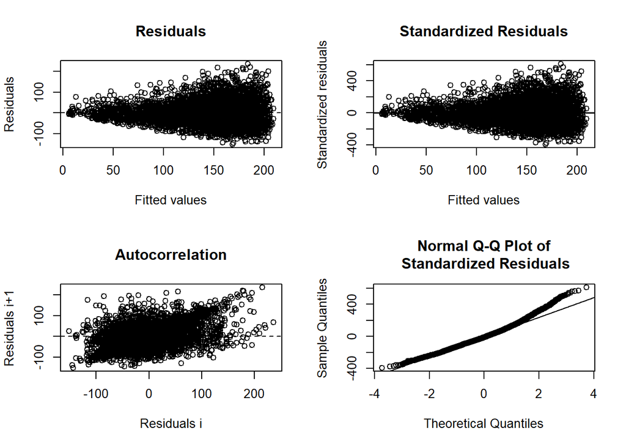

## predict and plot

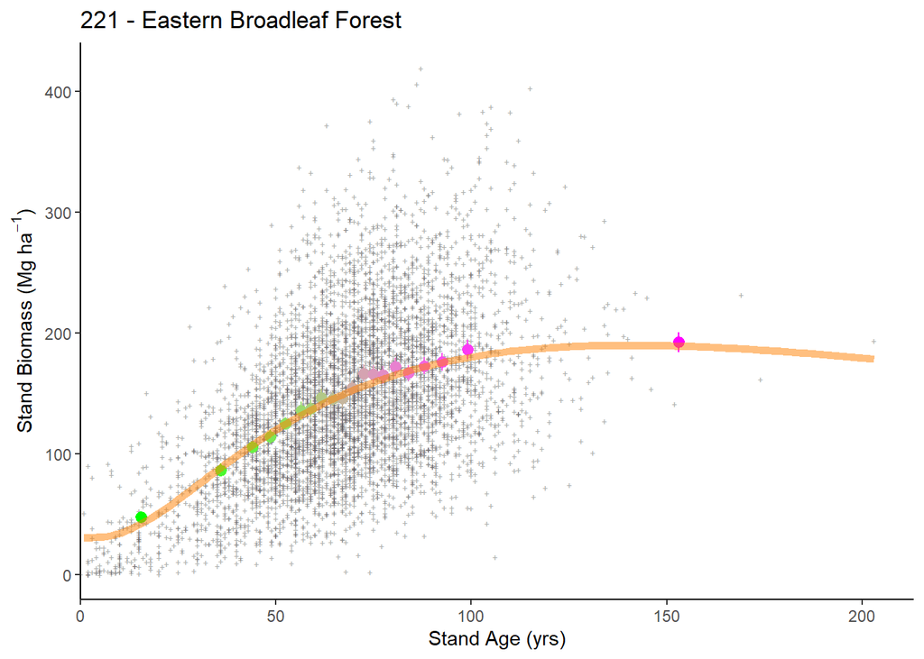

## plotting 2

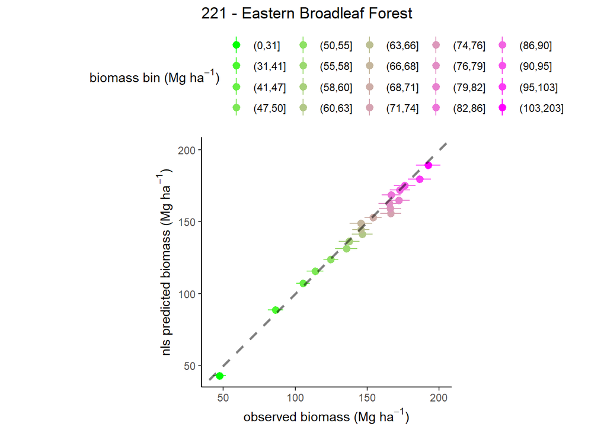

# 222 - Midwest Broadleaf Forest

## model selection 1

```
## Analysis of Variance Table
##
## Model 1: B_plt_t2_MgHa ~ (1 + (MEASTIME_t2 - 1990) * ge/100) * (a + b * exp(-((log(STDAGE_t2/c))/d)^2))
## Model 2: B_plt_t2_MgHa ~ (1 + (MEASTIME_t2 - 1990) * ge/100) * (1 + phi * DeltaPDSI) * (a + b * exp(-((log(STDAGE_t2/c))/d)^2))
## Model 3: B_plt_t2_MgHa ~ (1 + (MEASTIME_t2 - 1990) * ge/100) * (1 + phi * DeltaPDSI) * (1 - alpha * B_L_prop) * (a + b * exp(-((log(STDAGE_t2/c))/d)^2))
##   Res.Df Res.Sum Sq Df Sum Sq F value  Pr(>F)
## 1   3241     966.66
## 2   3240     964.73  1  1.926  6.4695 0.01102 *
## 3   3236     886.27  4 78.460 71.6186 < 2e-16 ***
## ---
## Signif. codes:  0 '***' 0.001 '**' 0.01 '*' 0.05 '.' 0.1 ' ' 1
```

```
##   model      AIC
## 1     1 34973.43
## 2     2 34968.95
## 3     3 34674.16
```

```
##
## Formula: B_plt_t2_MgHa ~ (1 + (MEASTIME_t2 - 1990) * ge/100) * (1 + phi *
##     DeltaPDSI) * (1 - alpha * B_L_prop) * (a + b * exp(-((log(STDAGE_t2/c))/d)^2))
##
## Parameters:
##        Estimate Std. Error t value Pr(>|t|)
## ge      0.05841    0.24066   0.243  0.80825
## phi     0.03750    0.01193   3.144  0.00168 **
## alpha   0.88978    0.04731  18.808  < 2e-16 ***
## a      25.02011    2.17660  11.495  < 2e-16 ***
## b     115.79193    6.76395  17.119  < 2e-16 ***
## c     106.46528    6.03631  17.637  < 2e-16 ***
## d       1.04715    0.06142  17.048  < 2e-16 ***
## ---
## Signif. codes:  0 '***' 0.001 '**' 0.01 '*' 0.05 '.' 0.1 ' ' 1
##
## Residual standard error: 0.5233 on 3236 degrees of freedom
##
## Algorithm "port", convergence message: relative convergence (4)
##   (5 observations deleted due to missingness)
```

### summary

- simple model: fits
- phi model: fits
- phi-alpha model: fits

## plot residuals

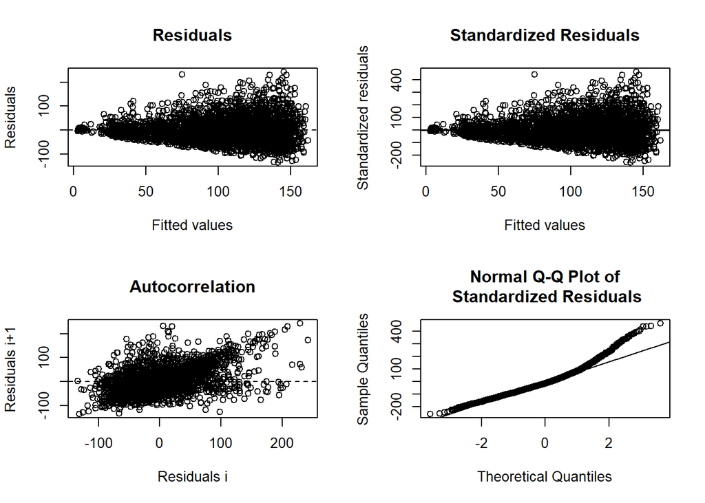

```
##
## ------
##  Shapiro-Wilk normality test
##
## data:  stdres
## W = 0.95564, p-value < 2.2e-16
##
##
## ------
```

```
##
##  Runs Test
##
## data:  as.factor(run)
## Standard Normal = -23.694, p-value < 2.2e-16
## alternative hypothesis: two.sided
```

## predict and plot

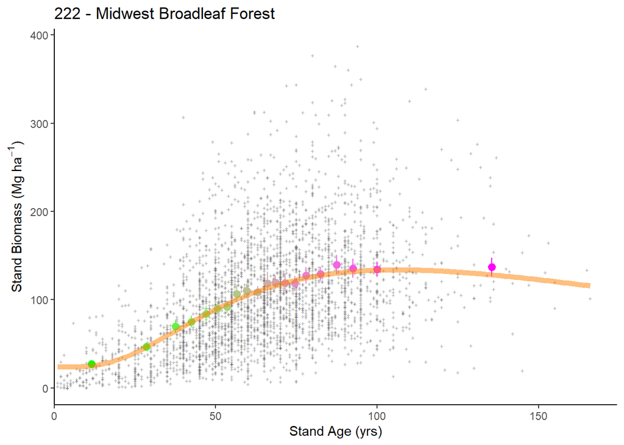

## plotting 2

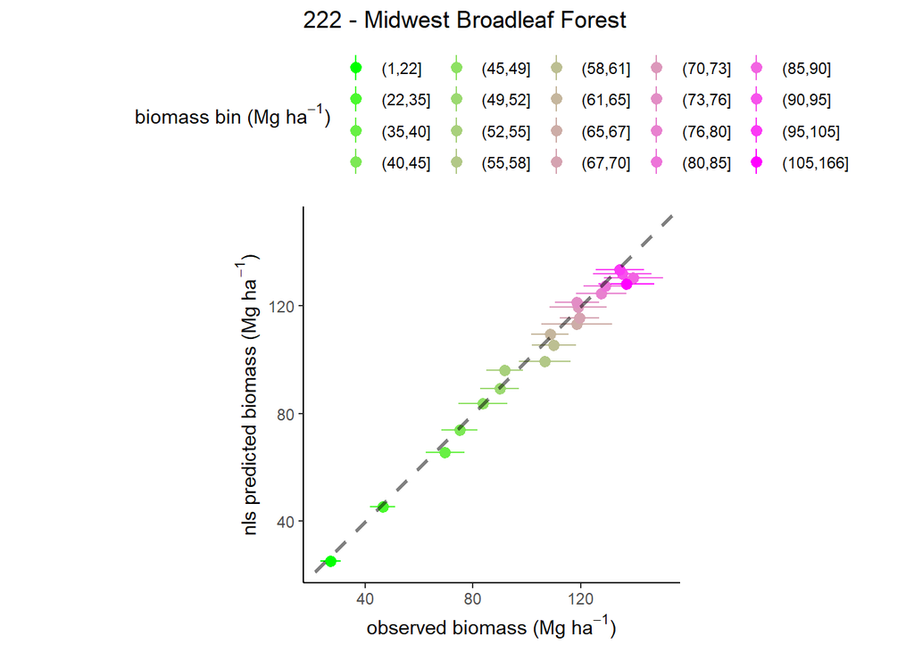

# 223 - Central Interior Broadleaf Forest

## model selection 1

```
## Analysis of Variance Table
##
## Model 1: B_plt_t2_MgHa ~ (1 + (MEASTIME_t2 - 1990) * ge/100) * (a + b * exp(-((log(STDAGE_t2/c))/d)^2))
## Model 2: B_plt_t2_MgHa ~ (1 + (MEASTIME_t2 - 1990) * ge/100) * (1 + phi * DeltaPDSI) * (a + b * exp(-((log(STDAGE_t2/c))/d)^2))
## Model 3: B_plt_t2_MgHa ~ (1 + (MEASTIME_t2 - 1990) * ge/100) * (1 + phi * DeltaPDSI) * (1 - alpha * B_L_prop) * (a + b * exp(-((log(STDAGE_t2/c))/d)^2))
##   Res.Df Res.Sum Sq Df Sum Sq F value Pr(>F)
## 1   6036     1080.5
## 2   6035     1080.5  1  0.000    0.00      1
## 3   6032      992.4  3 88.119  178.53 <2e-16 ***
## ---
## Signif. codes:  0 '***' 0.001 '**' 0.01 '*' 0.05 '.' 0.1 ' ' 1
##   model      AIC
## 1     1 63295.87
## 2     2 63297.87
## 3     3 62770.35
```

```
##
## Formula: B_plt_t2_MgHa ~ (1 + (MEASTIME_t2 - 1990) * ge/100) * (1 + phi *
##     DeltaPDSI) * (1 - alpha * B_L_prop) * (a + b * exp(-((log(STDAGE_t2/c))/d)^2))
##
## Parameters:
##        Estimate Std. Error t value Pr(>|t|)
## ge    2.343e-01  1.282e-01   1.828   0.0676 .
## phi   0.000e+00  6.311e-03   0.000   1.0000
## alpha 7.812e-01  3.150e-02  24.797   <2e-16 ***
## a     3.188e+01  3.091e+00  10.315   <2e-16 ***
## b     1.034e+02  4.962e+00  20.833   <2e-16 ***
## c     1.120e+02  6.982e+00  16.036   <2e-16 ***
## d     1.293e+00  8.201e-02  15.761   <2e-16 ***
## ---
## Signif. codes:  0 '***' 0.001 '**' 0.01 '*' 0.05 '.' 0.1 ' ' 1
##
## Residual standard error: 0.4056 on 6032 degrees of freedom
##
## Algorithm "port", convergence message: relative convergence (4)
##   (7 observations deleted due to missingness)
```

### summary

- simple model: fits
- phi model: fits
- phi-alpha model: fits

## plot residuals

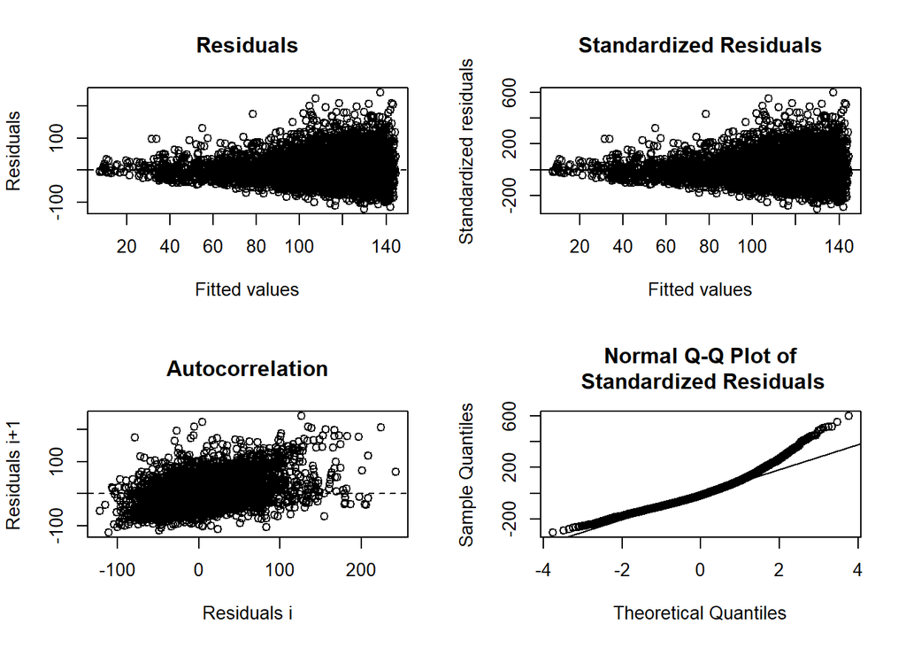

## predict and plot

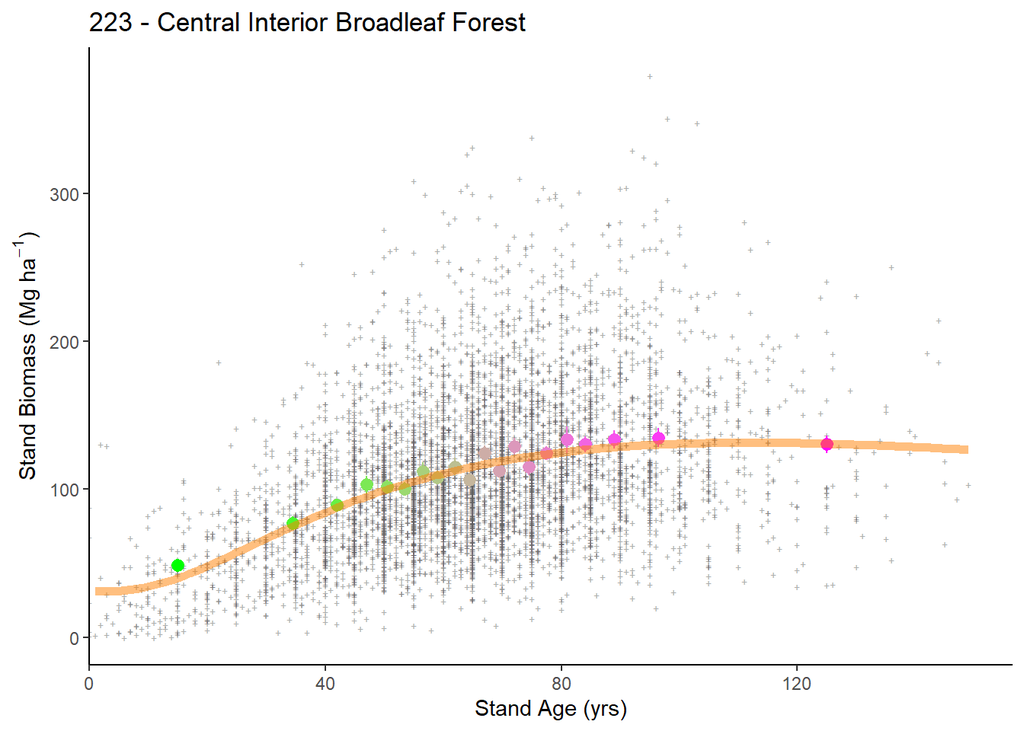

## plotting 2

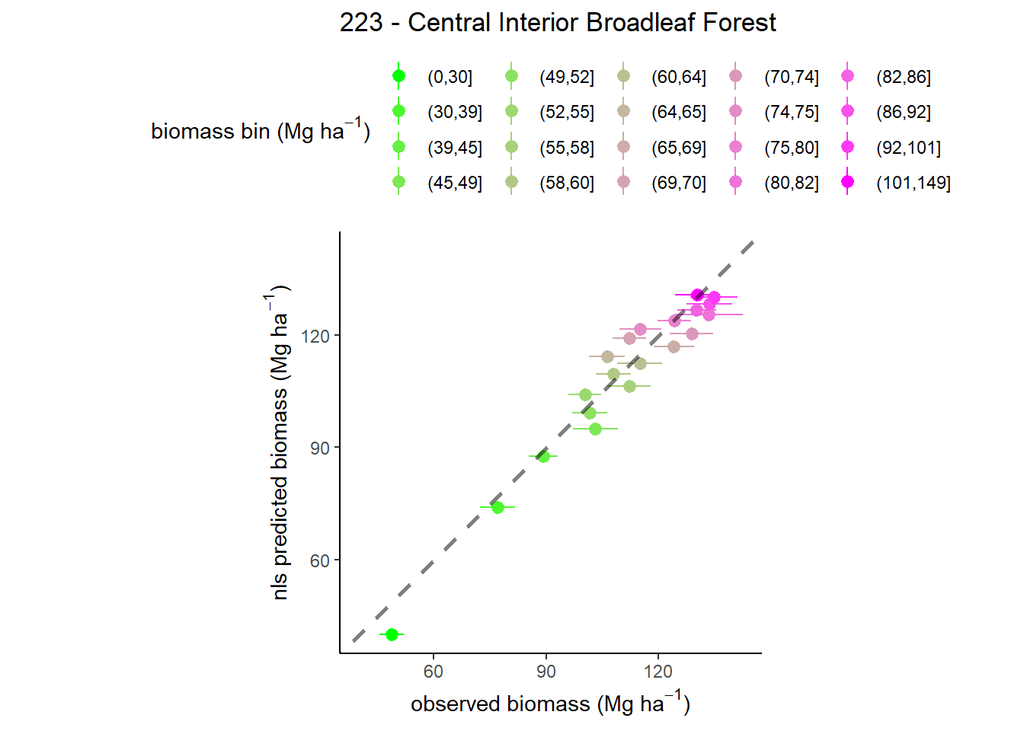

# 231 - Southeastern Mixed Forest

## model selection 1

```
## Analysis of Variance Table
##
## Model 1: B_plt_t2_MgHa ~ (1 + (MEASTIME_t2 - 1990) * ge/100) * (a + b * exp(-((log(STDAGE_t2/c))/d)^2))
## Model 2: B_plt_t2_MgHa ~ (1 + (MEASTIME_t2 - 1990) * ge/100) * (1 + phi * DeltaPDSI) * (a + b * exp(-((log(STDAGE_t2/c))/d)^2))
## Model 3: B_plt_t2_MgHa ~ (1 + (MEASTIME_t2 - 1990) * ge/100) * (1 + phi * DeltaPDSI) * (1 - alpha * B_L_prop) * (a + b * exp(-((log(STDAGE_t2/c))/d)^2))
##   Res.Df Res.Sum Sq Df Sum Sq F value Pr(>F)
## 1   7521     1961.5
## 2   7520     1961.5  1   0.00       0      1
## 3   7519     1760.1  1 201.32     860 <2e-16 ***
## ---
## Signif. codes:  0 '***' 0.001 '**' 0.01 '*' 0.05 '.' 0.1 ' ' 1
##   model      AIC
## 1     1 81724.18
## 2     2 81726.18
## 3     3 80913.14
```

```
##
## Formula: B_plt_t2_MgHa ~ (1 + (MEASTIME_t2 - 1990) * ge/100) * (1 + phi *
##     DeltaPDSI) * (1 - alpha * B_L_prop) * (a + b * exp(-((log(STDAGE_t2/c))/d)^2))
##
## Parameters:
##        Estimate Std. Error t value Pr(>|t|)
## ge    1.638e+00  1.672e-01   9.796   <2e-16 ***
## phi   0.000e+00  5.521e-03   0.000        1
## alpha 7.285e-01  2.005e-02  36.332   <2e-16 ***
## a     2.443e+01  1.015e+00  24.063   <2e-16 ***
## b     1.095e+02  4.857e+00  22.547   <2e-16 ***
## c     1.088e+02  7.891e+00  13.787   <2e-16 ***
## d     1.481e+00  6.355e-02  23.305   <2e-16 ***
## ---
## Signif. codes:  0 '***' 0.001 '**' 0.01 '*' 0.05 '.' 0.1 ' ' 1
##
## Residual standard error: 0.4838 on 7519 degrees of freedom
##
## Algorithm "port", convergence message: relative convergence (4)
##   (6 observations deleted due to missingness)
```

### summary

- simple model: fits
- phi model: fits
- phi-alpha model: fits

## plot residuals

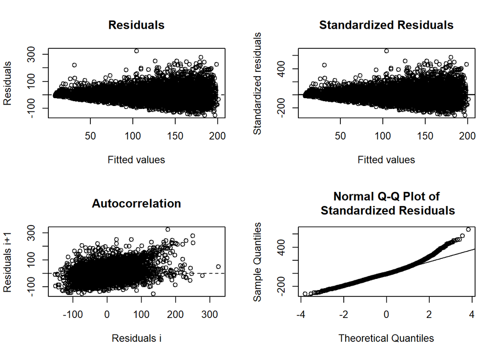

## predict and plot

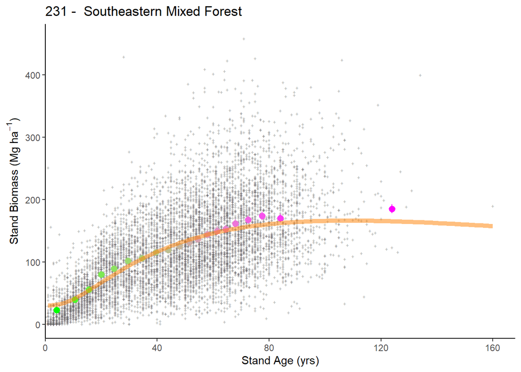

## plotting 2

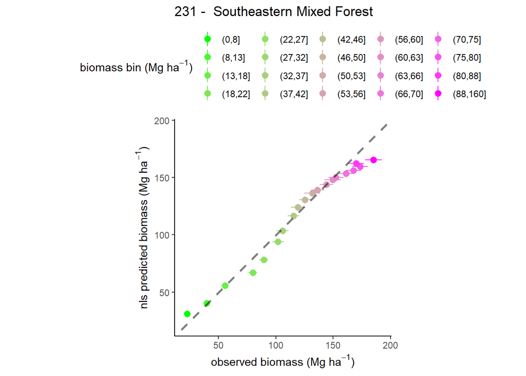

# 232 - Outer Coastal Plain Mixed Forest

## model selection 1

```
## Analysis of Variance Table
##
## Model 1: B_plt_t2_MgHa ~ (1 + (MEASTIME_t2 - 1990) * ge/100) * (a + b * exp(-((log(STDAGE_t2/c))/d)^2))
## Model 2: B_plt_t2_MgHa ~ (1 + (MEASTIME_t2 - 1990) * ge/100) * (1 + phi * DeltaPDSI) * (a + b * exp(-((log(STDAGE_t2/c))/d)^2))
## Model 3: B_plt_t2_MgHa ~ (1 + (MEASTIME_t2 - 1990) * ge/100) * (1 + phi * DeltaPDSI) * (1 - alpha * B_L_prop) * (a + b * exp(-((log(STDAGE_t2/c))/d)^2))
##   Res.Df Res.Sum Sq Df  Sum Sq F value    Pr(>F)
## 1   7552     2926.0
## 2   7551     2919.8  1   6.201  16.036 6.274e-05 ***
## 3   7550     2714.4  1 205.405 571.325 < 2.2e-16 ***
## ---
## Signif. codes:  0 '***' 0.001 '**' 0.01 '*' 0.05 '.' 0.1 ' ' 1
##   model      AIC
## 1     1 83857.40
## 2     2 83843.36
## 3     3 83294.11
```

```
##
## Formula: B_plt_t2_MgHa ~ (1 + (MEASTIME_t2 - 1990) * ge/100) * (1 + phi *
##     DeltaPDSI) * (1 - alpha * B_L_prop) * (a + b * exp(-((log(STDAGE_t2/c))/d)^2))
##
## Parameters:
##        Estimate Std. Error t value Pr(>|t|)
## ge    1.119e+00  1.787e-01   6.263 3.99e-10 ***
## phi   2.457e-02  6.946e-03   3.538 0.000406 ***
## alpha 7.035e-01  2.332e-02  30.174  < 2e-16 ***
## a     2.473e+01  1.280e+00  19.322  < 2e-16 ***
## b     1.179e+02  6.428e+00  18.339  < 2e-16 ***
## c     1.224e+02  1.175e+01  10.420  < 2e-16 ***
## d     1.554e+00  8.091e-02  19.211  < 2e-16 ***
## ---
## Signif. codes:  0 '***' 0.001 '**' 0.01 '*' 0.05 '.' 0.1 ' ' 1
##
## Residual standard error: 0.5996 on 7550 degrees of freedom
##
## Algorithm "port", convergence message: relative convergence (4)
##   (11 observations deleted due to missingness)
```

### summary

- simple model: fits
- phi model: fits
- phi-alpha model: fits

## plot residuals

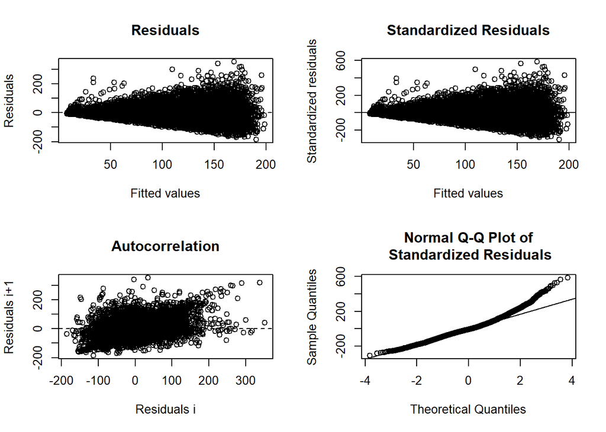

## predict and plot

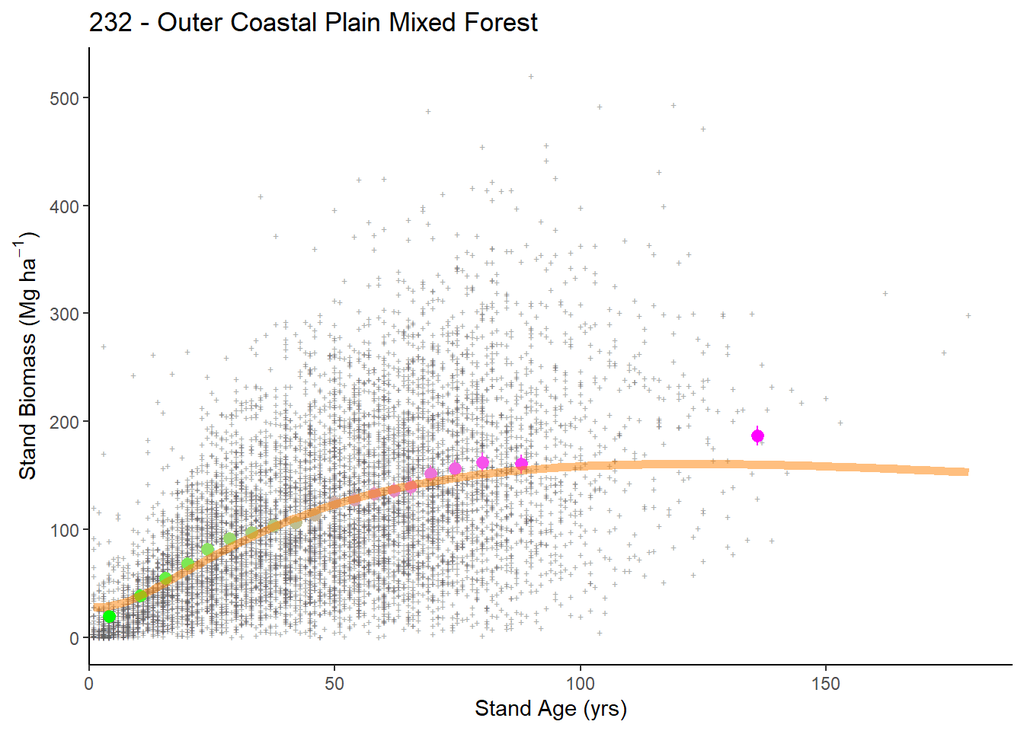

## plotting 2

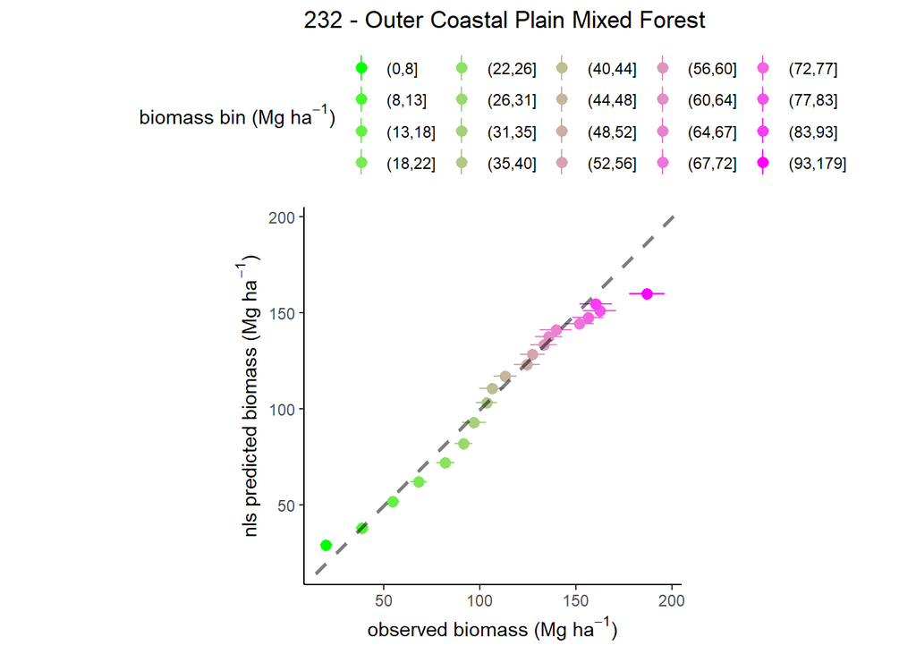

# 234 - Lower Mississippi Riverine Forest

## model selection 1

```
## Error in nls(f_ln_1, data = G_234, start = c(ge = ge.start, a = a.start,  :
##   Convergence failure: iteration limit reached without convergence (10)
## Analysis of Variance Table
##
## Model 1: B_plt_t2_MgHa ~ (1 + (MEASTIME_t2 - 1990) * ge/100) * (1 + phi * DeltaPDSI) * (a + b * exp(-((log(STDAGE_t2/c))/d)^2))
## Model 2: B_plt_t2_MgHa ~ (1 + (MEASTIME_t2 - 1990) * ge/100) * (1 + phi * DeltaPDSI) * (1 - alpha * B_L_prop) * (a + b * exp(-((log(STDAGE_t2/c))/d)^2))
##   Res.Df Res.Sum Sq Df Sum Sq F value    Pr(>F)
## 1    776     196.69
## 2    775     170.70  1 25.984  117.97 < 2.2e-16 ***
## ---
## Signif. codes:  0 '***' 0.001 '**' 0.01 '*' 0.05 '.' 0.1 ' ' 1
##   model      AIC
## 1     1       NA
## 2     2 8668.035
## 3     3 8559.235
```

```
##
## Formula: B_plt_t2_MgHa ~ (1 + (MEASTIME_t2 - 1990) * ge/100) * (1 + phi *
##     DeltaPDSI) * (1 - alpha * B_L_prop) * (a + b * exp(-((log(STDAGE_t2/c))/d)^2))
##
## Parameters:
##        Estimate Std. Error t value Pr(>|t|)
## ge    2.759e-01  5.025e-01   0.549    0.583
## phi   1.327e-02  2.271e-02   0.584    0.559
## alpha 8.171e-01  6.762e-02  12.083   <2e-16 ***
## a     0.000e+00  5.014e+01   0.000    1.000
## b     6.835e+02  2.855e+03   0.239    0.811
## c     5.000e+03  6.044e+04   0.083    0.934
## d     3.531e+00  5.338e+00   0.662    0.508
## ---
## Signif. codes:  0 '***' 0.001 '**' 0.01 '*' 0.05 '.' 0.1 ' ' 1
##
## Residual standard error: 0.4693 on 775 degrees of freedom
##
## Algorithm "port", convergence message: relative convergence (4)
##   (2 observations deleted due to missingness)
```

### summary

- simple model: does not fit
- phi model: fits
- phi-alpha model: fits

## plot residuals

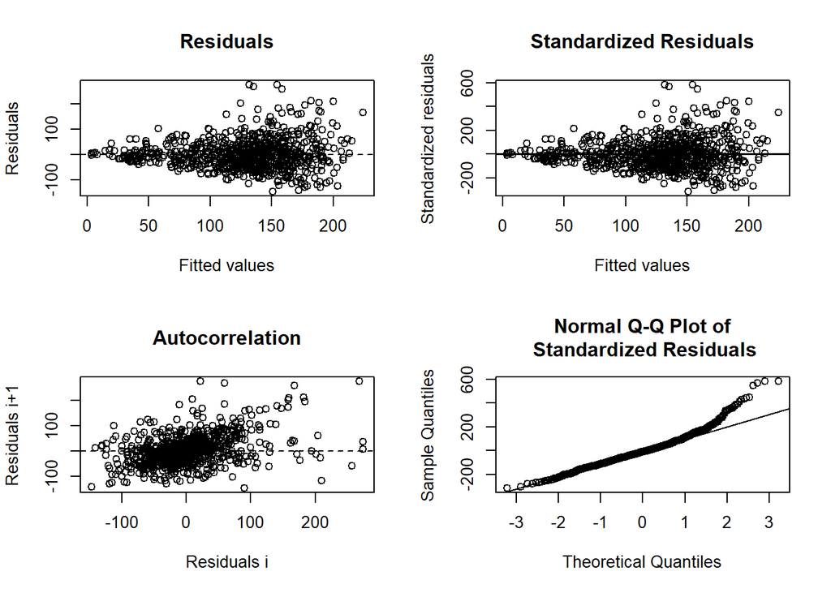

```
##
## ------
##  Shapiro-Wilk normality test
##
## data:  stdres
## W = 0.95363, p-value = 5.528e-15
##
##
## ------
```

```
##
##  Runs Test
##
## data:  as.factor(run)
## Standard Normal = -9.4959, p-value < 2.2e-16
## alternative hypothesis: two.sided
```

## predict and plot

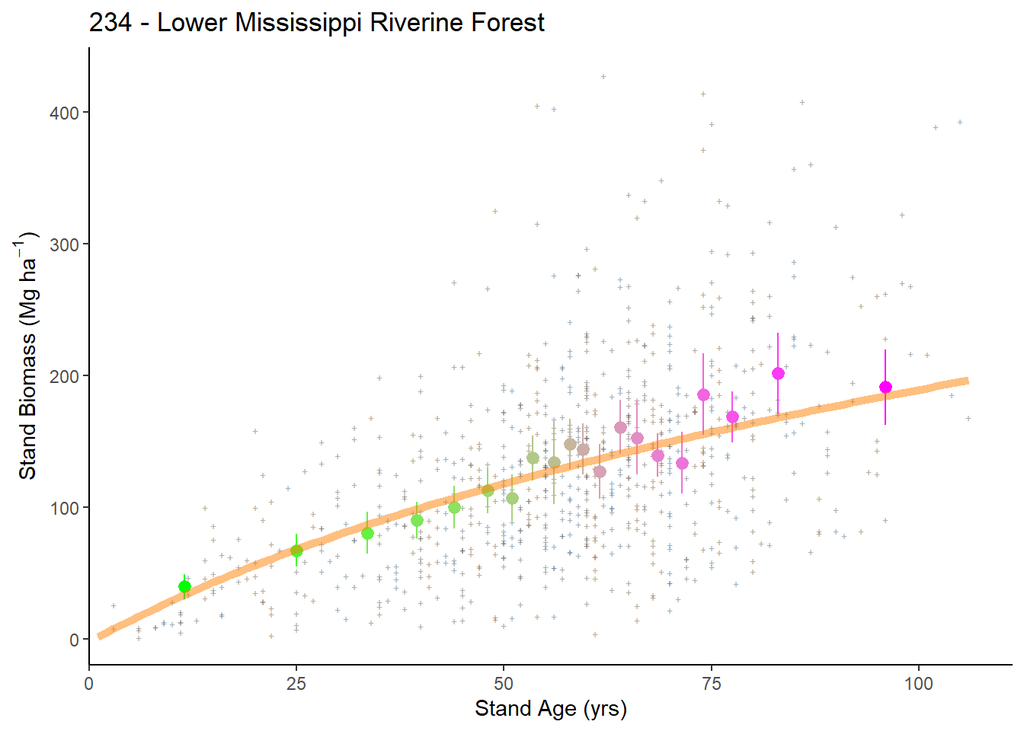

## plotting 2

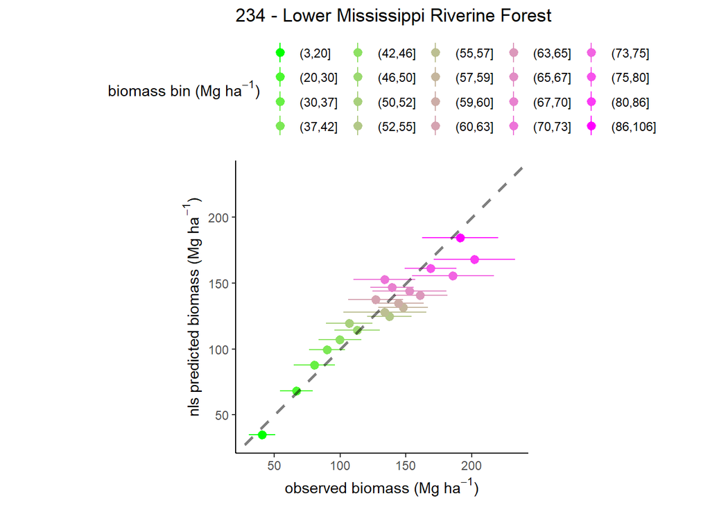

# 242 - Pacific Lowland Mixed Forest

## model selection 1

[output not shown]

```
## Error in get(paste("nls_242.", Mod.Sel1, sep = "")) :
##   object 'nls_242.' not found
```

### summary

- simple model: does not fit
- phi model: does not fit
- phi-alpha model: does not fit

## plot residuals

```
## [1] "cannot plot residuals"
```

## predict and plot

```
## [1] "cannot plot data with prediction"
```

## plotting 2

```
## [1] "cannot plot observed vs. predicted"
```

# 251 - Prairie Parkland (Temperate)

## model selection 1

```
## Analysis of Variance Table
##
## Model 1: B_plt_t2_MgHa ~ (1 + (MEASTIME_t2 - 1990) * ge/100) * (a + b * exp(-((log(STDAGE_t2/c))/d)^2))
## Model 2: B_plt_t2_MgHa ~ (1 + (MEASTIME_t2 - 1990) * ge/100) * (1 + phi * DeltaPDSI) * (a + b * exp(-((log(STDAGE_t2/c))/d)^2))
## Model 3: B_plt_t2_MgHa ~ (1 + (MEASTIME_t2 - 1990) * ge/100) * (1 + phi * DeltaPDSI) * (1 - alpha * B_L_prop) * (a + b * exp(-((log(STDAGE_t2/c))/d)^2))
##   Res.Df Res.Sum Sq Df Sum Sq F value    Pr(>F)
## 1   1242     254.97
## 2   1241     254.97  1  0.000   0.000         1
## 3   1240     241.91  1 13.061  66.951 6.838e-16 ***
## ---
## Signif. codes:  0 '***' 0.001 '**' 0.01 '*' 0.05 '.' 0.1 ' ' 1
##   model      AIC
## 1     1 12939.92
## 2     2 12941.92
## 3     3 12878.34
```

```
##
## Formula: B_plt_t2_MgHa ~ (1 + (MEASTIME_t2 - 1990) * ge/100) * (1 + phi *
##     DeltaPDSI) * (1 - alpha * B_L_prop) * (a + b * exp(-((log(STDAGE_t2/c))/d)^2))
##
## Parameters:
##        Estimate Std. Error t value Pr(>|t|)
## ge      0.34152    0.36829   0.927  0.35394
## phi     0.00000    0.01444   0.000  1.00000
## alpha   0.69993    0.07973   8.778  < 2e-16 ***
## a      23.46397    7.60340   3.086  0.00207 **
## b      98.81354   11.80570   8.370  < 2e-16 ***
## c     110.33191   12.98720   8.495  < 2e-16 ***
## d       1.24201    0.17315   7.173 1.26e-12 ***
## ---
## Signif. codes:  0 '***' 0.001 '**' 0.01 '*' 0.05 '.' 0.1 ' ' 1
##
## Residual standard error: 0.4417 on 1240 degrees of freedom
##
## Algorithm "port", convergence message: relative convergence (4)
##   (1 observation deleted due to missingness)
```

### summary

- simple model: fits
- phi model: fits
- phi-alpha model: fits

## plot residuals

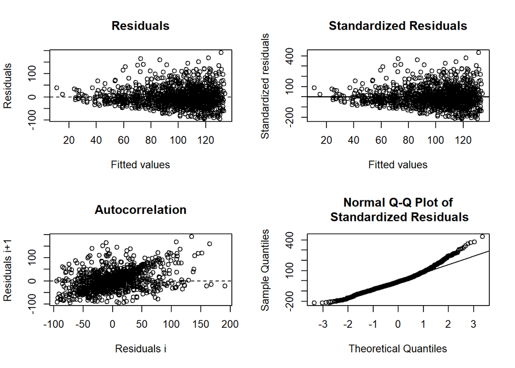

```
##
## ------
##  Shapiro-Wilk normality test
##
## data:  stdres
## W = 0.96733, p-value = 3.753e-16
##
##
## ------
```

```
##
##  Runs Test
##
## data:  as.factor(run)
## Standard Normal = -12.834, p-value < 2.2e-16
## alternative hypothesis: two.sided
```

## predict and plot

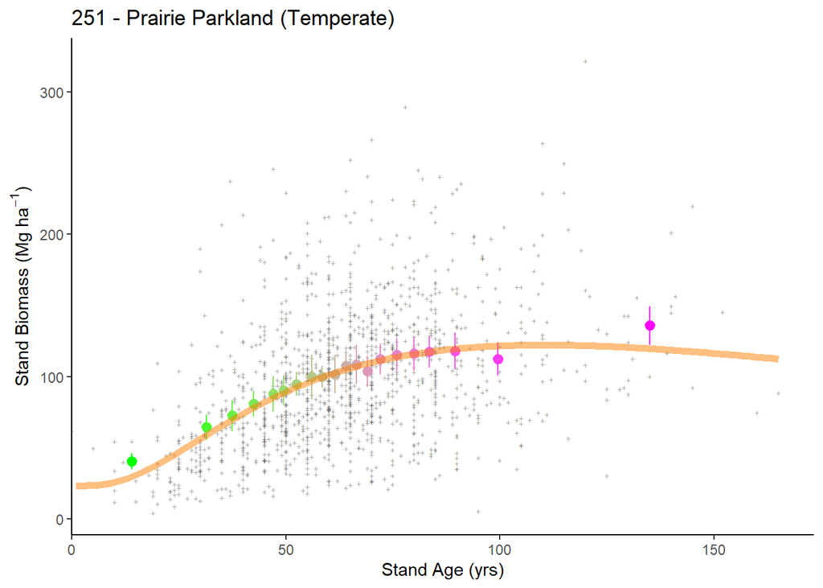

## plotting 2

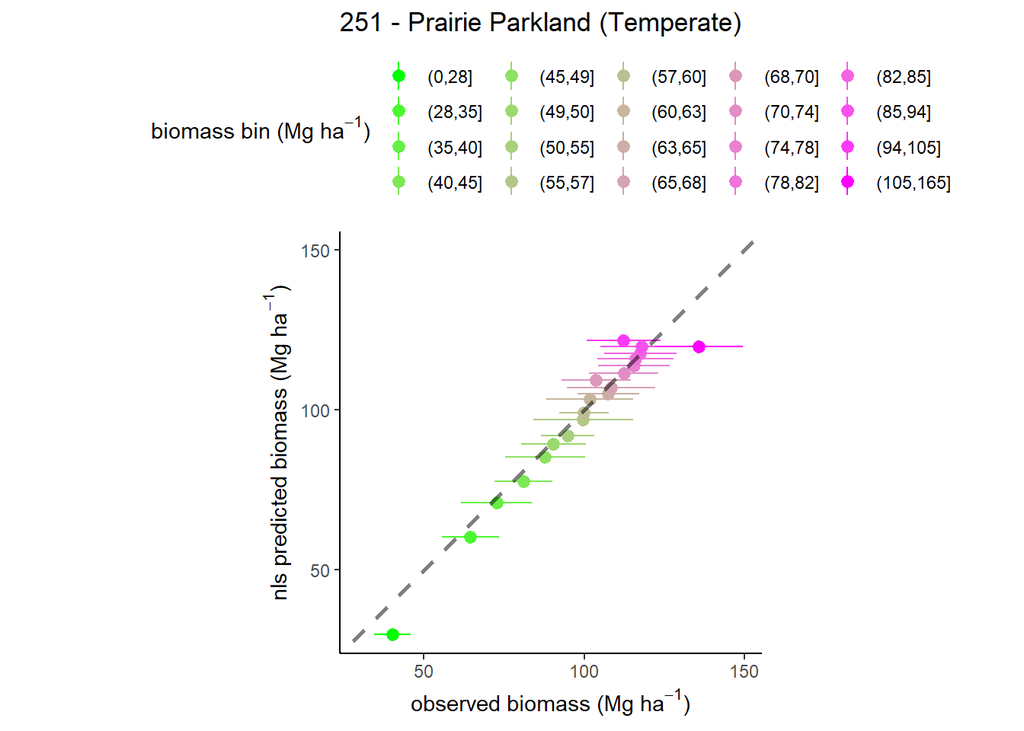

# 255 - Prairie Parkland (Subtropical)

## model selection 1

```
## Analysis of Variance Table
##
## Model 1: B_plt_t2_MgHa ~ (1 + (MEASTIME_t2 - 1990) * ge/100) * (a + b * exp(-((log(STDAGE_t2/c))/d)^2))
## Model 2: B_plt_t2_MgHa ~ (1 + (MEASTIME_t2 - 1990) * ge/100) * (1 + phi * DeltaPDSI) * (a + b * exp(-((log(STDAGE_t2/c))/d)^2))
## Model 3: B_plt_t2_MgHa ~ (1 + (MEASTIME_t2 - 1990) * ge/100) * (1 + phi * DeltaPDSI) * (1 - alpha * B_L_prop) * (a + b * exp(-((log(STDAGE_t2/c))/d)^2))
##   Res.Df Res.Sum Sq Df Sum Sq F value    Pr(>F)
## 1    403     122.41
## 2    402     122.35  1 0.0617  0.2026    0.6528
## 3    401     112.60  1 9.7510 34.7260 8.051e-09 ***
## ---
## Signif. codes:  0 '***' 0.001 '**' 0.01 '*' 0.05 '.' 0.1 ' ' 1
##   model      AIC
## 1     1 4138.171
## 2     2 4139.965
## 3     3 4108.080
```

```
##
## Formula: B_plt_t2_MgHa ~ (1 + (MEASTIME_t2 - 1990) * ge/100) * (1 + phi *
##     DeltaPDSI) * (1 - alpha * B_L_prop) * (a + b * exp(-((log(STDAGE_t2/c))/d)^2))
##
## Parameters:
##       Estimate Std. Error t value Pr(>|t|)
## ge     0.04016    0.46932   0.086 0.931854
## phi    0.00000    0.03628   0.000 1.000000
## alpha  0.80165    0.12265   6.536 1.93e-10 ***
## a     19.87084    5.86637   3.387 0.000776 ***
## b     74.30714   10.23179   7.262 1.99e-12 ***
## c     57.29565    6.22746   9.200  < 2e-16 ***
## d      1.07411    0.16998   6.319 7.01e-10 ***
## ---
## Signif. codes:  0 '***' 0.001 '**' 0.01 '*' 0.05 '.' 0.1 ' ' 1
##
## Residual standard error: 0.5299 on 401 degrees of freedom
##
## Algorithm "port", convergence message: relative convergence (4)
##   (2 observations deleted due to missingness)
```

### summary

- simple model: fits
- phi model: fits
- phi-alpha model: fits

## plot residuals

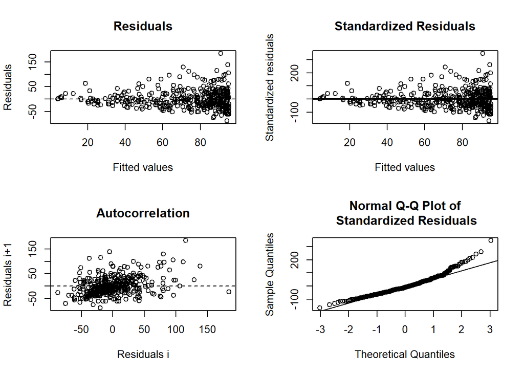

```
##
## ------
##  Shapiro-Wilk normality test
##
## data:  stdres
## W = 0.94713, p-value = 6.817e-11
##
##
## ------
```

```
##
##  Runs Test
##
## data:  as.factor(run)
## Standard Normal = -6.6848, p-value = 2.312e-11
## alternative hypothesis: two.sided
```

## predict and plot

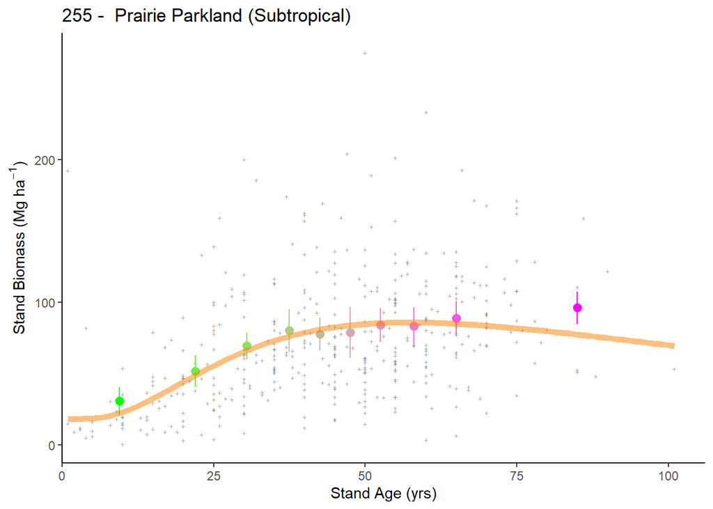

## plotting 2

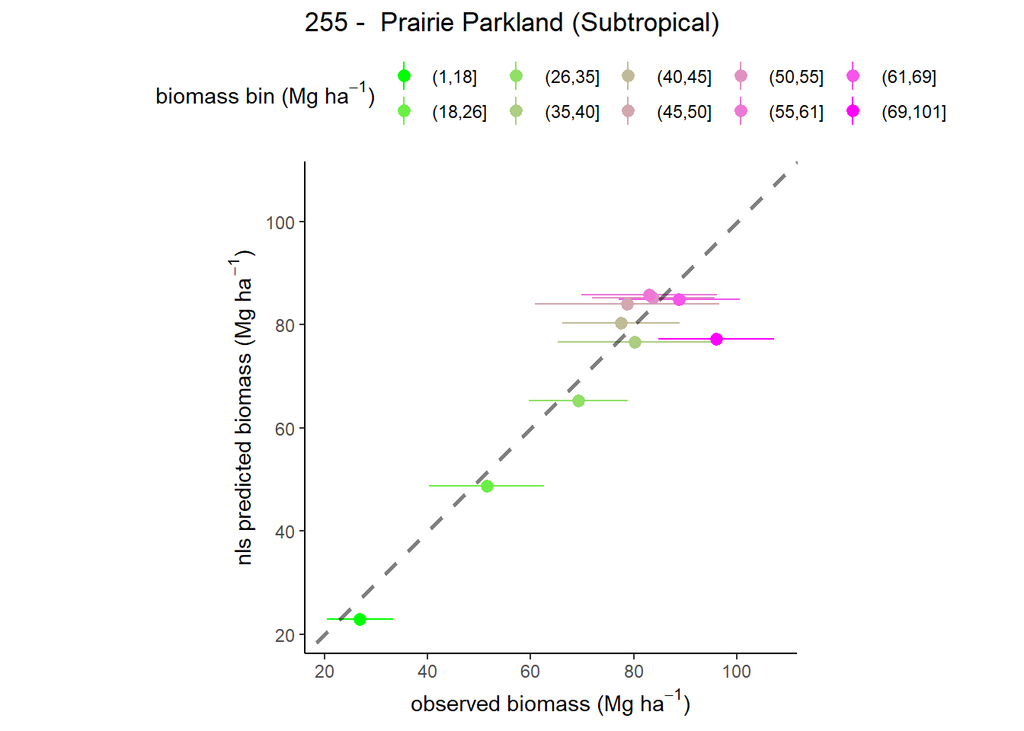

# 261 - California Coastal Chaparral Forest and Shrub

## model selection 1

[output not shown]

```
## Error in get(paste("nls_261.", Mod.Sel1, sep = "")) :
##   object 'nls_261.' not found
```

### summary

- simple model: does not fit
- phi model: does not fit
- phi-alpha model: does not fit
- unable to fit model (only 64 observations)

## plot residuals

```
## [1] "cannot plot residuals"
```

## predict and plot

```
## [1] "cannot plot data with prediction"
```

## plotting 2

```
## [1] "cannot plot observed vs. predicted"
```

# 262 - California Dry Steppe

## model selection 1

[output not shown]

```
## Error in get(paste("nls_262.", Mod.Sel1, sep = "")) :
##   object 'nls_262.' not found
```

### summary

- simple model: does not fit
- phi model: does not fit
- phi-alpha model: does not fit
- unable to fit model (0 observations)

## plot residuals

```
## [1] "cannot plot residuals"
```

## predict and plot

```
## [1] "cannot plot data with prediction"
```

## plotting 2

```
## [1] "cannot plot observed vs. predicted"
```

# 263 - California Coastal Steppe - Mixed Forest and Redwood Forest

## model selection 1

[output not shown]

```
## Error in get(paste("nls_263.", Mod.Sel1, sep = "")) :
##   object 'nls_263.' not found
```

### summary

- simple model: does not fit
- phi model: does not fit
- phi-alpha model: does not fit

## plot residuals

```
## [1] "cannot plot residuals"
```

## predict and plot

```
## [1] "cannot plot data with prediction"
```

## plotting 2

```
## [1] "cannot plot observed vs. predicted"
```

# 313 - Colorado Plateau Semi-Desert

## model selection 1

[output not shown]

```
## Error in get(paste("nls_313.", Mod.Sel1, sep = "")) :
##   object 'nls_313.' not found
```

### summary

- simple model: does not fit
- phi model: does not fit
- phi-alpha model: does not fit

## plot residuals

```
## [1] "cannot plot residuals"
```

## predict and plot

```
## [1] "cannot plot data with prediction"
```

## plotting 2

```
## [1] "cannot plot observed vs. predicted"
```

# 315 - Southwest Plateau and Plains Dry Steppe and Shrub

## model selection 1

### summary

- simple model: does not fit
- phi model: does not fit
- phi-alpha model: does not fit

## plot residuals

```
## [1] "cannot plot residuals"
```

## predict and plot

```
## [1] "cannot plot data with prediction"
```

## plotting 2

```
## [1] "cannot plot observed vs. predicted"
```

# 321 - Chihuahuan Semi-Desert

## model selection 1

### summary

- simple model: does not fit
- phi model: does not fit
- phi-alpha model: does not fit

## plot residuals

```
## [1] "cannot plot residuals"
```

## predict and plot

```
## [1] "cannot plot data with prediction"
```

## plotting 2

```
## [1] "cannot plot observed vs. predicted"
```

# 322 - American Semidesert and Desert

## model selection 1

### summary

- simple model: does not fit
- phi model: does not fit
- phi-alpha model: does not fit

## plot residuals

```
## [1] "cannot plot residuals"
```

## predict and plot

```
## [1] "cannot plot data with prediction"
```

## plotting 2

```
## [1] "cannot plot observed vs. predicted"
```

- Cannot fit model
- not enough data (only 3 observations)

# 331 - Great Plains/Palouse Dry Steppe

## model selection 1

### summary

- simple model: does not fit
- phi model: does not fit
- phi-alpha model: does not fit

## plot residuals

```
## [1] "cannot plot residuals"
```

## predict and plot

```
## [1] "cannot plot data with prediction"
```

## plotting 2

```
## [1] "cannot plot observed vs. predicted"
```

- Cannot fit model

# 332 - Great Plains Steppe

## plot residuals

```
## [1] "cannot plot residuals"
```

## predict and plot

[figure not shown]

## plotting 2

[figure not shown]